# LUCIDus Comprehensive Guide: Models, APIs, and End-to-End Functionality

## 1) Purpose of This Document

LUCID (Latent Unknown Clusters by Integrating multi-omics Data) finds latent subgroups of subjects that are simultaneously (1) predictable from a set of exposures `G`, (2) characterized by distinct omics profiles `Z`, and (3) associated with a health outcome `Y`. This document is a comprehensive, user-facing tour of the package’s **public API**: everything a user needs to fit, tune, summarize, predict from, bootstrap, and visualize a LUCID model, worked through end to end on a small simulated dataset. It intentionally does not describe internal implementation details – only functions you are meant to call directly.

It covers:

- the three model architectures and what each one assumes:
  - **early integration** – one joint set of clusters from all omics layers pooled together
  - **parallel integration** – one cluster variable per omics layer, fit jointly
  - **serial integration** – a chain of cluster stages, each built on the previous stage’s cluster assignment
- fitting APIs: `estimate_lucid()`, `tune_lucid()`, `lucid()`
- post-fit APIs: `summary()`, `predict_lucid()` (including `g_computation` mode), `boot_lucid()`, `plot()`, `plot_cluster_omic_profile()`
- extractor functions for a fitted model’s output: `get_selected_G()`, `get_selected_Z()`, `get_cluster_assignment()`, `get_top_omics_features()`
- missing-data diagnostics and imputation: `check_na()`, `analyze_missing_pattern()`, `safe_impute()`, `check_imputation_quality()`

## 2) Quick Functionality Map

| Functionality | Main API |
| --- | --- |
| Fit early/parallel/serial model directly | `estimate_lucid()` |
| Grid search for `K` and penalties | `tune_lucid()` |
| One-step wrapper (fit or tune+fit) | `lucid()` |
| Structured model summary | `summary()` |
| Prediction and cluster assignment on new/held-out data | `predict_lucid()` |
| Bootstrap CI inference | `boot_lucid()` |
| Sankey-style path visualization | `plot()` |
| Per-cluster omics profile visualization | `plot_cluster_omic_profile()` |
| Extract selected exposures / omics features from a fit | `get_selected_G()`, `get_selected_Z()` |
| Extract hard cluster assignment from a fit | `get_cluster_assignment()` |
| Extract top-N most important omics features from a fit | `get_top_omics_features()` |
| Missingness diagnostics | `check_na()`, `analyze_missing_pattern()` |
| Robust imputation helpers | `safe_impute()`, `check_imputation_quality()` |

The four `get_*()` extractors share one design point worth calling out up front: every one of them takes only the fitted model object and figures out on its own whether it is looking at an early, parallel, or serial fit. You never pass a `lucid_model` argument to them, and (since this release) `predict_lucid()` and `boot_lucid()` no longer require one either – they detect it from `class(model)`. The only place you still name the model type explicitly is when *fitting* one, since that is the argument that decides which architecture gets fit in the first place.

## 3) Setup

```r
library(LUCIDus)
```

## 4) Build Associated Demo Data (Not Independent Sampling)

A LUCID model only has something interesting to find if `G`, the latent cluster, `Z`, and `Y` are actually related – fitting it to independent noise would produce arbitrary clusters and make every example below meaningless. This simulation deliberately wires in that structure: a subset of exposures in `G` drive a binary latent state `x`, `x` in turn shifts each omics layer’s means apart (so the layers actually separate by cluster) and shifts the outcome `Y`. That known ground truth is also what lets the fitted models’ recovered clusters and selected features be checked for sanity throughout this document.

```r
make_demo_data <- function(n = 80, pG = 6, pZ = 4, seed = 20260309) {
  set.seed(seed)

  # Exposures
  G <- matrix(rnorm(n * pG), nrow = n, ncol = pG)
  colnames(G) <- paste0("G", seq_len(pG))

  # Covariates associated with exposures
  CoG <- cbind(
    cov_g1 = G[, 1] + 0.2 * G[, 2] + rnorm(n, sd = 0.2),
    cov_g2 = -0.3 * G[, 3] + 0.4 * G[, 4] + rnorm(n, sd = 0.25)
  )
  CoY <- CoG

  # Latent cluster driver
  lin <- 1.0 * G[, 1] - 0.8 * G[, 2] + 0.4 * CoG[, 1]
  prob_x <- plogis(lin)
  x <- rbinom(n, size = 1, prob = prob_x)

  # Layer 1 and 2 for parallel stage
  Z1 <- cbind(
    1.2 * x + 0.5 * G[, 1] + rnorm(n, sd = 0.5),
    1.0 * x - 0.4 * G[, 2] + rnorm(n, sd = 0.5),
    0.8 * x + 0.3 * G[, 3] + rnorm(n, sd = 0.5),
    0.6 * x + 0.2 * G[, 4] + rnorm(n, sd = 0.5)
  )

  Z2 <- cbind(
    -1.1 * x + 0.45 * G[, 2] + rnorm(n, sd = 0.5),
    -0.9 * x - 0.35 * G[, 1] + rnorm(n, sd = 0.5),
    -0.7 * x + 0.25 * G[, 5] + rnorm(n, sd = 0.5),
    -0.5 * x + 0.20 * G[, 6] + rnorm(n, sd = 0.5)
  )

  # Layer 3 for serial second stage (early stage)
  Z3 <- cbind(
    0.9 * x + 0.30 * G[, 1] + rnorm(n, sd = 0.55),
    0.7 * x - 0.25 * G[, 3] + rnorm(n, sd = 0.55),
    -0.8 * x + 0.20 * G[, 4] + rnorm(n, sd = 0.55),
    -0.6 * x + 0.15 * G[, 6] + rnorm(n, sd = 0.55)
  )

  colnames(Z1) <- paste0("Z1_f", seq_len(pZ))
  colnames(Z2) <- paste0("Z2_f", seq_len(pZ))
  colnames(Z3) <- paste0("Z3_f", seq_len(pZ))

  # Outcomes
  Y_normal <- 1.1 * x + 0.5 * G[, 1] - 0.25 * G[, 3] + 0.35 * CoY[, 2] + rnorm(n, sd = 0.7)
  Y_binary <- rbinom(n, size = 1, prob = plogis(-0.2 + 1.0 * x + 0.35 * G[, 1] - 0.2 * CoY[, 1]))

  # Structures for each model
  Z_parallel <- list(layer1 = Z1, layer2 = Z2)
  Z_early <- cbind(Z1, Z2)
  Z_serial_mixed <- list(list(layer1 = Z1, layer2 = Z2), Z3)

  list(
    G = G,
    CoG = CoG,
    CoY = CoY,
    Y_normal = as.numeric(Y_normal),
    Y_binary = as.numeric(Y_binary),
    Z1 = Z1,
    Z2 = Z2,
    Z3 = Z3,
    Z_parallel = Z_parallel,
    Z_early = Z_early,
    Z_serial_mixed = Z_serial_mixed
  )
}

d <- make_demo_data()
```

The three `Z_*` structures at the bottom – `Z_early` (one concatenated matrix), `Z_parallel` (a named list of layer matrices), `Z_serial_mixed` (a list whose first element is itself a parallel-style list) – are exactly the three shapes `estimate_lucid()` expects for early, parallel, and serial fitting respectively. Building all three up front from the same underlying `Z1`/`Z2`/`Z3` layers means every model type below is fit on data that differ only in how the layers are packaged, not in what they contain.

## 5) Add Missingness for Diagnostics and Missing-Data Examples

Multi-omics studies rarely have complete data: whole layers can be missing for a subject (e.g. a blood sample was never collected – “listwise” missingness within that layer), or a handful of individual features can be missing sporadically. LUCID’s EM fitting handles both patterns natively – the missing-data helpers in section 6 exist to let you check that handling, not to do it manually. This chunk injects both patterns into copies of the data built above, purely so the diagnostics in section 6 have something to report on.

```r
# Early matrix missingness
Z_early_miss <- d$Z_early
Z_early_miss[1, ] <- NA          # listwise
Z_early_miss[2:4, 1] <- NA       # sporadic block
Z_early_miss[5, 3] <- NA         # sporadic cell

# Parallel list missingness
Z_parallel_miss <- d$Z_parallel
Z_parallel_miss[[1]][1, ] <- NA  # listwise on layer1
Z_parallel_miss[[2]][2, 2] <- NA # sporadic on layer2

# Serial mixed missingness (stage1 parallel + stage2 early)
Z_serial_miss <- list(
  list(
    layer1 = Z_parallel_miss[[1]],
    layer2 = Z_parallel_miss[[2]]
  ),
  {tmp <- d$Z3; tmp[3, ] <- NA; tmp}
)
```

## 6) Missing-Data Diagnostics and Imputation

`estimate_lucid()` imputes missing omics values internally, conditional on the current model fit, as part of its EM loop – there is no separate “impute first, then fit” step for you to run. What the two functions below give you is *visibility* into that process: whether the missingness pattern looks the way you expect, and whether a quick standalone imputation of the same data is directionally sane.

### 6.1 `analyze_missing_pattern()` and `check_na()`

`analyze_missing_pattern()` reports how much data is missing and how it is distributed; `check_na()` additionally classifies, per subject and per omics layer, which missingness pattern applies (fully observed, listwise missing, or sporadically missing) – the same three-way classification the EM loop itself uses internally to decide how to handle each subject.

```r
miss_info_early <- analyze_missing_pattern(Z_early_miss)
na_early <- check_na(Z_early_miss, lucid_model = "early")
na_parallel <- check_na(Z_parallel_miss, lucid_model = "parallel")

miss_info_early$total_missing
```

```
## [1] 0.01875
```

```r
table(na_early$indicator_na)
```

```
##
##  1  2  3
## 75  4  1
```

```r
na_parallel$cross_layer_summary
```

```
## $n_layers
## [1] 2
##
## $n_observations
## [1] 80
##
## $features_per_layer
## layer1 layer2
##      4      4
##
## $missing_pattern_counts
##
## 1 1 1 2 3 1
##  78   1   1
##
## $total_missing_prop
## [1] 0.0078125
```

### 6.2 `safe_impute()` and `check_imputation_quality()`

`safe_impute()` is a standalone imputation you can run outside of model fitting – useful for a quick look at the data, or for a workflow that needs a complete matrix for some other purpose before ever calling `estimate_lucid()`. `check_imputation_quality()` then scores how plausible the imputed values are relative to the observed distribution of each column.

```r
# Use a sub-matrix for concise display
orig_sub <- Z_early_miss[, 1:4, drop = FALSE]
imputed_sub <- safe_impute(orig_sub, method = "mean")
quality_sub <- check_imputation_quality(orig_sub, imputed_sub)

quality_sub$overall_quality
```

[output not shown]

`overall_quality` summarizes, across all imputed cells, how close the filled values landed to each column’s observed range and variance – a low score here would flag an imputation that looks implausible (e.g. a filled value far outside the observed range), which is worth knowing about a data set even before it reaches `estimate_lucid()`. `estimate_lucid()`’s own internal imputation is more informed than this standalone version – it fills a missing value conditional on the fitted cluster structure and covariance, re-estimated at every EM iteration, rather than with a single fixed column statistic – but the two are checking the same basic question: are the filled-in values sane?

## 7) Core Model Fitting: `estimate_lucid()`

`estimate_lucid()` is the single entry point for fitting any of the three architectures at one fixed `K` (number of clusters) and one fixed penalty. `lucid_model` picks the architecture; everything else (`G`, `Z`, `Y`, `family`, `K`, the `Rho_*` penalties) has the same meaning across all three. `Rho_G` penalizes the `G -> cluster` coefficients toward zero (an exposure whose coefficient is driven to exactly zero is “not selected”); `Rho_Z_Mu` and `Rho_Z_Cov` do the analogous thing for the omics mean/covariance structure, so weakly-differentiating features can be zeroed out of the cluster definition. This guide fits at `Rho_* = 0` throughout for simplicity and speed; the 3-model tutorials walk through the penalized-screen-then- zero-penalty-refit workflow that real feature selection uses.

### 7.1 Early model

Early integration concatenates every omics layer into one matrix and fits **one** cluster variable from the pooled features – the right choice when you expect a single latent state to manifest across all your omics layers at once.

```r
set.seed(101)
fit_early <- estimate_lucid(
  lucid_model = "early",
  G = d$G,
  Z = Z_early_miss,
  Y = d$Y_normal,
  CoG = d$CoG,
  CoY = d$CoY,
  family = "normal",
  K = 2,
  Rho_G = 0,
  Rho_Z_Mu = 0,
  Rho_Z_Cov = 0,
  max_itr = 8,
  max_tot.itr = 30,
  tol = 1e-2,
  seed = 101,
  verbose = FALSE
)
```

```
## Fitting LUCID early model (K = 2)...
```

```
## Finished LUCID early model.
```

```r
class(fit_early)
```

```
## [1] "early_lucid"
```

Every field below is documented on `?estimate_lucid`’s `@return`; the same field names and shapes are used across all three model types where a field applies to more than one. Rather than reading `fit_early$select$selectG` directly, use `get_selected_G()`/`get_selected_Z()` – they return the same information as a named vector and auto-detect the model type, so the same call works unchanged if `fit_early` were swapped for a parallel or serial fit later in a script.

```r
names(fit_early)
```

```
##  [1] "res_Beta"             "res_Mu"               "res_Sigma"
##  [4] "res_Gamma"            "K"                    "var.names"
##  [7] "init_omic.data.model" "likelihood"           "inclusion.p"
## [10] "family"               "select"               "useY"
## [13] "Z"                    "init_impute"          "init_par"
## [16] "Rho"                  "missing_summary"      "em_control"
```

```r
cat("likelihood:", fit_early$likelihood, "\n")
```

```
## likelihood: -650.09
```

```r
cat("selected G:", sum(get_selected_G(fit_early)), "of",
    length(get_selected_G(fit_early)), "\n")
```

```
## selected G: 6 of 6
```

```r
cat("selected Z:", sum(get_selected_Z(fit_early)), "of",
    length(get_selected_Z(fit_early)), "\n")
```

```
## selected Z: 8 of 8
```

At `Rho_G = Rho_Z_Mu = 0` nothing is actually penalized out, so every exposure and every omics feature is reported “selected” here – the counts become informative once a positive penalty is applied, as in the 3-model tutorials’ screening step.

### 7.2 Parallel model

Parallel integration fits a **separate** cluster variable per omics layer, jointly, rather than pooling the layers into one. Use this when the layers plausibly reflect different underlying processes – e.g. a metabolomic subtype and a methylation subtype need not coincide – and you want each to be discovered on its own terms rather than forced into a single joint cluster.

```r
set.seed(102)
fit_parallel <- estimate_lucid(
  lucid_model = "parallel",
  G = d$G,
  Z = Z_parallel_miss,
  Y = d$Y_normal,
  CoG = d$CoG,
  CoY = d$CoY,
  family = "normal",
  K = c(2, 2),
  Rho_G = 0,
  Rho_Z_Mu = 0,
  Rho_Z_Cov = 0,
  max_itr = 8,
  max_tot.itr = 30,
  tol = 1e-2,
  seed = 102,
  verbose = FALSE
)
```

```
## Fitting LUCID parallel model (2 layers)...
```

```
## Finished LUCID parallel model.
```

```r
class(fit_parallel)
```

```
## [1] "lucid_parallel"
```

Two fields differ from the early fit above: `N` (sample size) is present here but not for early, and `z` (the joint E-step responsibility array across layers, before it is marginalized into `inclusion.p`) appears only for parallel. `get_selected_G()` takes an optional `layer` argument here, since a parallel fit can select a different exposure subset per layer.

```r
names(fit_parallel)
```

```
##  [1] "res_Beta"             "res_Mu"               "res_Sigma"
##  [4] "res_Gamma"            "K"                    "N"
##  [7] "var.names"            "init_omic.data.model" "likelihood"
## [10] "inclusion.p"          "family"               "select"
## [13] "useY"                 "Z"                    "z"
## [16] "init_impute"          "init_par"             "Rho"
## [19] "missing_summary"      "em_control"
```

```r
cat("N:", fit_parallel$N, "\n")
```

```
## N: 80
```

```r
cat("selected G per layer:", paste(sapply(seq_along(fit_parallel$K), function(i)
                                     sum(get_selected_G(fit_parallel, layer = i))),
                                   collapse = ", "), "\n")
```

```
## selected G per layer: 6, 6
```

```r
sel_z_parallel <- get_selected_Z(fit_parallel)
cat("selected Z per layer:", paste(sapply(sel_z_parallel, sum), collapse = ", "), "\n")
```

```
## selected Z per layer: 4, 4
```

`get_selected_Z()` returns a list here, one logical vector per layer, since “which omics features are selected” is itself a per-layer question for a parallel fit.

### 7.3 Serial model (mixed topology)

Serial integration chains stages together: stage 1’s cluster assignment becomes (part of) stage 2’s input, and so on. It suits a mediation-like hypothesis – e.g. exposures act on an early biological layer, which in turn shapes a later one, which in turn shapes the outcome. Any stage can itself be early or parallel; the fit below mixes a parallel first stage (two omics layers) with an early second stage (one layer), which is the most general configuration the package supports.

```r
set.seed(103)
fit_serial <- estimate_lucid(
  lucid_model = "serial",
  G = d$G,
  Z = Z_serial_miss,
  Y = d$Y_normal,
  CoG = d$CoG,
  CoY = d$CoY,
  family = "normal",
  K = list(list(2, 2), 2),
  Rho_G = 0,
  Rho_Z_Mu = 0,
  Rho_Z_Cov = 0,
  max_itr = 8,
  max_tot.itr = 36,
  tol = 1e-2,
  seed = 103,
  verbose = FALSE
)
```

```
## Fitting LUCID serial model (2 stages)...
```

```
##   Stage 1/2 (parallel) finished: log-likelihood = -607.523.
```

```
##   Stage 2/2 (early) finished: log-likelihood = -399.220.
## Finished LUCID serial model.
```

```r
class(fit_serial)
```

```
## [1] "lucid_serial"
```

```r
length(fit_serial$submodel)
```

```
## [1] 2
```

Serial adds `submodel` (the fitted stage models, each a complete `early_lucid`/`lucid_parallel` object) and `res_Delta` (between-stage transition coefficients). `likelihood` and `select` are present, same as early/parallel, but are aggregates: `likelihood` sums each stage’s own log-likelihood (no single joint EM loop exists to report one from), and `select` is stage 1’s own selection only – the one stage whose `G` is the cohort’s real exposures, not a previous stage’s cluster probabilities. `get_selected_G()` on a serial fit always returns stage 1’s selection for the same reason; `get_selected_Z()` returns a list, one element per stage, shaped like whatever that stage’s own architecture is (a vector for an early stage, a list of layers for a parallel stage).

```r
names(fit_serial)
```

```
##  [1] "res_Beta"             "res_Mu"               "res_Sigma"
##  [4] "res_Delta"            "res_Gamma"            "K"
##  [7] "N"                    "var.names"            "init_omic.data.model"
## [10] "inclusion.p"          "family"               "useY"
## [13] "Z"                    "init_impute"          "init_par"
## [16] "submodel"             "missing_summary"      "Rho"
## [19] "em_control"           "likelihood"           "select"
```

```r
cat("top-level likelihood (sum over stages):", fit_serial$likelihood, "\n")
```

```
## top-level likelihood (sum over stages): -1006.743
```

```r
cat("top-level select is stage 1's select:",
    identical(fit_serial$select, fit_serial$submodel[[1]]$select), "\n")
```

```
## top-level select is stage 1's select: TRUE
```

```r
sel_z_serial <- get_selected_Z(fit_serial)
cat("stage 1 (parallel) selected Z per layer:",
    paste(sapply(sel_z_serial[[1]], sum), collapse = ", "), "\n")
```

```
## stage 1 (parallel) selected Z per layer: 4, 4
```

```r
cat("stage 2 (early) selected Z:", sum(sel_z_serial[[2]]), "\n")
```

```
## stage 2 (early) selected Z: 4
```

### 7.4 Verbose Logging Demos (`verbose = TRUE`)

`verbose = TRUE` prints one line per EM iteration – the current log-likelihood and, where relevant, the change since the last iteration – which is the fastest way to confirm a fit is actually converging (steadily increasing, then flattening) rather than diverging or oscillating. The fits below are intentionally lightweight (a 30-subject subsample, tiny iteration caps) and only serve to show what that log looks like for each architecture.

```r
n_demo <- 30
G_demo <- d$G[1:n_demo, , drop = FALSE]
Y_demo <- d$Y_normal[1:n_demo]
CoG_demo <- d$CoG[1:n_demo, , drop = FALSE]
CoY_demo <- d$CoY[1:n_demo, , drop = FALSE]
Z_early_demo <- d$Z_early[1:n_demo, , drop = FALSE]
Z_parallel_demo <- lapply(d$Z_parallel, function(z) z[1:n_demo, , drop = FALSE])
Z_serial_demo <- list(
  lapply(d$Z_parallel, function(z) z[1:n_demo, , drop = FALSE]),
  d$Z3[1:n_demo, , drop = FALSE]
)

set.seed(111)
fit_early_verbose <- estimate_lucid(
  lucid_model = "early",
  G = G_demo,
  Z = Z_early_demo,
  Y = Y_demo,
  CoG = CoG_demo,
  CoY = CoY_demo,
  family = "normal",
  K = 2,
  Rho_G = 0,
  Rho_Z_Mu = 0,
  Rho_Z_Cov = 0,
  max_itr = 2,
  max_tot.itr = 8,
  tol = 1e-2,
  seed = 111,
  verbose = TRUE
)
```

```
## Initialize LUCID with mclust based on inclusion probabilities given by mclust
## Fitting Early Integration LUCID model (K = 2, Rho_G = 0, Rho_Z_Mu = 0, Rho_Z_Cov = 0)
## iteration 1 : E-step finished.
## iteration 1: log-likelihood = -211.863
## iteration 2 : E-step finished.
## iteration 2: log-likelihood = -207.327
## iteration 3 : E-step finished.
## iteration 3: log-likelihood = -207.288
```

```
## Finished LUCID early model: log-likelihood = -207.288.
```

```r
set.seed(112)
fit_parallel_verbose <- estimate_lucid(
  lucid_model = "parallel",
  G = G_demo,
  Z = Z_parallel_demo,
  Y = Y_demo,
  CoG = CoG_demo,
  CoY = CoY_demo,
  family = "normal",
  K = c(2, 2),
  Rho_G = 0,
  Rho_Z_Mu = 0,
  Rho_Z_Cov = 0,
  max_itr = 2,
  max_tot.itr = 8,
  tol = 1e-2,
  seed = 112,
  verbose = TRUE
)
```

```
## Fitting LUCID in Parallel model (K = 2, Rho_G = 0, Rho_Z_Mu = 0, Rho_Z_Cov = 0) (K = 2, Rho_G = 0, Rho_Z_Mu = 0, Rho_Z_Cov = 0)
## iteration 1 : E-step finished.
## iteration 1: log-likelihood = -241.834
## iteration 2 : E-step finished.
## iteration 2: log-likelihood = -241.139
```

```
## Finished LUCID parallel model: log-likelihood = -241.139.
```

```r
set.seed(113)
fit_serial_verbose <- estimate_lucid(
  lucid_model = "serial",
  G = G_demo,
  Z = Z_serial_demo,
  Y = Y_demo,
  CoG = CoG_demo,
  CoY = CoY_demo,
  family = "normal",
  K = list(list(2, 2), 2),
  Rho_G = 0,
  Rho_Z_Mu = 0,
  Rho_Z_Cov = 0,
  max_itr = 2,
  max_tot.itr = 10,
  tol = 1e-2,
  seed = 113,
  verbose = TRUE
)
```

```
## Fitting LUCID serial model (Stage 1/2)...
## Fitting LUCID in Parallel model (K = 2, Rho_G = 0, Rho_Z_Mu = 0, Rho_Z_Cov = 0) (K = 2, Rho_G = 0, Rho_Z_Mu = 0, Rho_Z_Cov = 0)
## iteration 1 : E-step finished.
## iteration 1: log-likelihood = -206.521
## iteration 2 : E-step finished.
## iteration 2: log-likelihood = -205.875
```

```
## Finished LUCID parallel model: log-likelihood = -205.875.
##
## Fitting LUCID serial model (Stage 2/2)...
## Initialize LUCID with mclust based on inclusion probabilities given by mclust
## Fitting Early Integration LUCID model (K = 2, Rho_G = 0, Rho_Z_Mu = 0, Rho_Z_Cov = 0)
## iteration 1 : E-step finished.
## iteration 1: log-likelihood = -156.096
## iteration 2 : E-step finished.
## iteration 2: log-likelihood = -153.735
## iteration 3 : E-step finished.
## iteration 3: log-likelihood = -152.525
```

```
## Finished LUCID early model: log-likelihood = -152.525.
##
## Success: LUCID serial model constructed!
```

## 8) Tuning and Wrapper APIs: `tune_lucid()` and `lucid()`

Choosing `K` and the penalty strengths by hand, as section 7 did, only works when you already have a good guess. `tune_lucid()` instead fits a whole grid of `K`/`Rho_*` combinations and reports each one’s BIC, so the combination that best balances fit against model complexity can be selected systematically rather than by trial and error. `lucid()` goes one step further: it runs the same tuning search, picks the BIC-best candidate, and – importantly – **refits that winner at zero penalty**, so the returned model’s coefficients are not shrunk by the same penalty that was used only to decide which features to keep. That two-step logic (penalized search for selection, zero-penalty refit for estimation) is worth remembering; the 3-model tutorials walk through doing it by hand for cases where more control over the refit is needed than `lucid()`’s default gives.

### 8.1 `tune_lucid()` with a small early-model grid

```r
set.seed(104)

tune_early <- tune_lucid(
  G = d$G,
  Z = d$Z_early,
  Y = d$Y_normal,
  CoG = d$CoG,
  CoY = d$CoY,
  family = "normal",
  lucid_model = "early",
  K = 2:3,
  Rho_G = 0,
  Rho_Z_Mu = 0,
  Rho_Z_Cov = 0,
  max_itr = 6,
  max_tot.itr = 24,
  seed = 104
)
```

```
## Fitting LUCID early model (K = 2)...
```

```
## Finished LUCID early model.
##
## ====================================================
## LUCID Early Integration: Model Summary
## ====================================================
##
## Model specification
##   Family                 : normal
##   Number of observations : 80
##   Number of clusters (K) : 2
##
## Missing-data profile
##   Listwise missing rows  : 0 / 80 (0.0%)
##   Sporadic missing rows  : 0 / 80 (0.0%)
##   Missing cells total    : 0 / 640 (0.0%)
##
## Feature selection overview
##   G features selected    : 6 / 6 (100.0%)
##   Z features selected    : 8 / 8 (100.0%)
##
## Model fit statistics
##   Log-likelihood         : -704.46
##   BIC                    : 1860.28
##   Number of parameters   : 103
##
## Regularization
##   Rho_G                  : 0.000
##   Rho_Z_Mu               : 0.000
##   Rho_Z_Cov              : 0.000
##
## Detailed parameter estimates
## (1) Y (continuous outcome): cluster 1 mean (intercept), mean differences for other clusters, and covariate effects
##                 Gamma
## (Intercept) 0.3125382
## cluster2    0.2619192
## cov_g1      0.6175223
## cov_g2      0.5320559
##
## (2) Z: mean of omics data for each latent cluster
##       mu_cluster1 mu_cluster2
## Z1_f1 -0.56900590   0.5170944
## Z1_f2  0.15183098   0.5103446
## Z1_f3 -0.12642173   0.4027654
## Z1_f4 -0.01756913   0.3191024
## Z2_f1 -0.09641616  -0.4994498
## Z2_f2  0.23868326  -0.4993390
## Z2_f3  0.25290360  -0.5092025
## Z2_f4  0.08254873  -0.3134526
##
## (3) E: intercept and odds ratio of being assigned to each latent cluster for each exposure
##                            beta         OR
## (Intercept).cluster2  2.3141047 10.1158624
## G1.cluster2           0.6683651  1.9510450
## G2.cluster2          -0.2712207  0.7624482
## G3.cluster2          -0.3940201  0.6743405
## G4.cluster2           0.9889927  2.6885250
## G5.cluster2          -0.6029099  0.5472170
## G6.cluster2          -0.1097568  0.8960520
## cov_g1.cluster2       0.2329658  1.2623383
## cov_g2.cluster2      -0.8264530  0.4375987
## Fitting LUCID early model (K = 3)...
```

```
## Finished LUCID early model.
##
## ====================================================
## LUCID Early Integration: Model Summary
## ====================================================
##
## Model specification
##   Family                 : normal
##   Number of observations : 80
##   Number of clusters (K) : 3
##
## Missing-data profile
##   Listwise missing rows  : 0 / 80 (0.0%)
##   Sporadic missing rows  : 0 / 80 (0.0%)
##   Missing cells total    : 0 / 640 (0.0%)
##
## Feature selection overview
##   G features selected    : 6 / 6 (100.0%)
##   Z features selected    : 8 / 8 (100.0%)
##
## Model fit statistics
##   Log-likelihood         : -667.52
##   BIC                    : 2027.40
##   Number of parameters   : 158
##
## Regularization
##   Rho_G                  : 0.000
##   Rho_Z_Mu               : 0.000
##   Rho_Z_Cov              : 0.000
##
## Detailed parameter estimates
## (1) Y (continuous outcome): cluster 1 mean (intercept), mean differences for other clusters, and covariate effects
##                  Gamma
## (Intercept) -0.3562758
## cluster2     0.6505660
## cluster3     1.2050978
## cov_g1       0.5174619
## cov_g2       0.5870936
##
## (2) Z: mean of omics data for each latent cluster
```

[output cut: 15 more lines]

```
## G3.cluster2          -0.7790547  0.45883954
## G4.cluster2           1.8085998  6.10189747
## G5.cluster2           1.3757889  3.95819813
## G6.cluster2          -1.9227067  0.14621067
## cov_g1.cluster2      -3.6739561  0.02537588
## cov_g2.cluster2      -0.8862642  0.41219276
## (Intercept).cluster3  3.3408897 28.24424309
## G1.cluster3           3.7131381 40.98221005
## G2.cluster3          -2.4721863  0.08440014
## G3.cluster3          -1.0152803  0.36230087
## G4.cluster3           0.3603281  1.43379981
## G5.cluster3           0.5800672  1.78615851
## G6.cluster3          -1.3117669  0.26934374
## cov_g1.cluster3      -1.7567726  0.17260102
## cov_g2.cluster3       0.4749526  1.60793799
```

```r
head(tune_early$tune_list)
```

```
##   K Rho_G Rho_Z_Mu Rho_Z_Cov      BIC
## 1 2     0        0         0 1860.275
## 2 3     0        0         0 2027.397
```

`tune_list` has one row per grid candidate, with its fitted `K`/penalty combination and its BIC; the lowest BIC in this table is the candidate `lucid()` (below) would have selected automatically.

### 8.2 `lucid()` wrapper (auto-tune over K for early model)

```r
set.seed(105)

fit_lucid_wrapper <- lucid(
  G = d$G,
  Z = d$Z_early,
  Y = d$Y_normal,
  CoG = d$CoG,
  CoY = d$CoY,
  family = "normal",
  lucid_model = "early",
  K = 2:3,
  Rho_G = 0,
  Rho_Z_Mu = 0,
  Rho_Z_Cov = 0,
  max_itr = 6,
  max_tot.itr = 24,
  seed = 105
)

class(fit_lucid_wrapper)
```

```
## [1] "early_lucid"
```

`fit_lucid_wrapper` is a complete `early_lucid` object – the same class `estimate_lucid()` would have returned had `K = 2:3`’s BIC-winner been fit directly – so it works with every function in this guide (`summary()`, `predict_lucid()`, the `get_*()` extractors) exactly like any other fit.

## 9) Summaries: `summary()`

```r
summary(fit_early)
```

```
##
## ====================================================
## LUCID Early Integration: Model Summary
## ====================================================
##
## Model specification
##   Family                 : normal
##   Number of observations : 80
##   Number of clusters (K) : 2
##
## Missing-data profile
##   Listwise missing rows  : 1 / 80 (1.2%)
##   Sporadic missing rows  : 4 / 80 (5.0%)
##   Missing cells total    : 12 / 640 (1.9%)
##
## Feature selection overview
##   G features selected    : 6 / 6 (100.0%)
##   Z features selected    : 8 / 8 (100.0%)
##
## Model fit statistics
##   Log-likelihood         : -650.09
##   BIC                    : 1751.53
##   Number of parameters   : 103
##
## Regularization
##   Rho_G                  : 0.000
##   Rho_Z_Mu               : 0.000
##   Rho_Z_Cov              : 0.000
##
## Detailed parameter estimates
## (1) Y (continuous outcome): cluster 1 mean (intercept), mean differences for other clusters, and covariate effects
##                 Gamma
## (Intercept) 0.1765857
## cluster2    1.0449481
## cov_g1      0.4929783
## cov_g2      0.6931914
##
## (2) Z: mean of omics data for each latent cluster
##         mu_cluster1 mu_cluster2
## Z1_f1 -0.0777814604   1.3323119
## Z1_f2  0.0840691217   1.1873927
## Z1_f3  0.0237814722   0.9834228
## Z1_f4  0.1617553558   0.5274073
## Z2_f1 -0.0021631579  -1.2547393
## Z2_f2  0.0001776934  -1.1894463
## Z2_f3 -0.1742793904  -0.8918661
## Z2_f4 -0.1083855071  -0.5296839
##
## (3) E: intercept and odds ratio of being assigned to each latent cluster for each exposure
##                             beta        OR
## (Intercept).cluster2 -0.86505853 0.4210269
## G1.cluster2           1.49321813 4.4513977
## G2.cluster2          -1.12634744 0.3242153
## G3.cluster2           0.19971412 1.2210536
## G4.cluster2          -0.55799151 0.5723575
## G5.cluster2          -0.27541536 0.7592567
## G6.cluster2           0.09558619 1.1003037
## cov_g1.cluster2       0.08560300 1.0893738
## cov_g2.cluster2       0.64058435 1.8975894
```

```r
summary(fit_parallel)
```

```
##
## ====================================================
## LUCID Parallel: Model Summary
## ====================================================
##
## Model specification
##   Family                 : gaussian
##   Number of observations : 80
##   Clusters per layer     : 2, 2
##
## Missing-data profile by layer
##   Layer 1 listwise rows : 1 / 80 (1.2%)
##   Layer 1 sporadic rows : 0 / 80 (0.0%)
##   Layer 1 missing cells : 4 / 320 (1.2%)
##   Layer 2 listwise rows : 0 / 80 (0.0%)
##   Layer 2 sporadic rows : 1 / 80 (1.2%)
##   Layer 2 missing cells : 1 / 320 (0.3%)
##
## Feature selection overview
##   G features selected    : 6 / 6 (100.0%)
##   G features by layer
##     Layer 1              : 6 / 6 (100.0%)
##     Layer 2              : 6 / 6 (100.0%)
##   Z features
##     Layer 1 selected     : 4 / 4 (100.0%)
##     Layer 1 multi-cluster: 4
##     Layer 2 selected     : 4 / 4 (100.0%)
##     Layer 2 multi-cluster: 4
##
## Model fit statistics
##   Log-likelihood         : -703.20
##   BIC                    : 1756.96
##   Number of parameters   : 80
##
## Regularization
##   Rho_G                  : 0.000
##   Rho_Z_Mu               : 0.000
##   Rho_Z_Cov              : 0.000
##
## Detailed parameter estimates
```

[output cut: 36 more lines]

```
## cov_g1.cluster2       0.94174788 2.5644599
## cov_g2.cluster2       1.08324695 2.9542563
##
## Layer 2
##
##                             beta         OR
## (Intercept).cluster2 -0.16662615  0.8465160
## G1.cluster2           3.59813736 36.5301286
## G2.cluster2          -1.28668079  0.2761860
## G3.cluster2           0.06073117  1.0626132
## G4.cluster2          -0.13557162  0.8732166
## G5.cluster2          -0.16105933  0.8512416
## G6.cluster2           0.05468855  1.0562116
## cov_g1.cluster2      -1.90949199  0.1481556
## cov_g2.cluster2       0.31059375  1.3642349
```

```r
summary(fit_serial)
```

```
##
## ====================================================
## LUCID Serial: Model Summary
## ====================================================
##
## Model specification
##   Family                 : normal
##   Number of observations : 80
##   Number of stages       : 2
##   Stage 1               : parallel (K = 2,2)
##   Stage 2               : early (K = 2)
##
## Missing-data profile by stage
##   Stage 1
##     Layer 1 listwise/sporadic rows : 1 / 0
##     Layer 2 listwise/sporadic rows : 0 / 1
##   Stage 2
##     Listwise rows         : 1
##     Sporadic rows         : 0
##
## Model fit statistics
##   Log-likelihood         : -1006.74
##   BIC                    : 2499.89
##
## Regularization
##   Rho_G                  : 0.000
##   Rho_Z_Mu               : 0.000
##   Rho_Z_Cov              : 0.000
##
## Stage-wise detailed parameter estimates
##
## --- Stage 1 (parallel) ---
##
## ====================================================
## LUCID Parallel: Model Summary
## ====================================================
##
## Model specification
##   Family                 : gaussian
##   Number of observations : 80
```

[output cut: 112 more lines]

```
## cov_g1       0.4964385
## cov_g2       0.4379221
##
## (2) Z: mean of omics data for each latent cluster
##       mu_cluster1 mu_cluster2
## Z3_f1 -0.42148130   0.5295890
## Z3_f2  0.25828699   0.3402714
## Z3_f3  0.26462045  -0.5481375
## Z3_f4 -0.07877362  -0.3163739
##
## (3) E: intercept and odds ratio of being assigned to each latent cluster for each cluster from the previous serial stage
##                                      beta           OR
## (Intercept).cluster2             42.07607 1.876740e+18
## Stage1.Layer1.cluster2.cluster2  59.87371 1.006518e+26
## Stage1.Layer2.cluster2.cluster2 -42.99601 2.123585e-19
```

At `Rho_* = 0` the selection overview above reports everything selected (as noted in section 7); with a positive penalty, this is the table that shows how much was screened out and at what rate.

## 10) Prediction: `predict_lucid()`

`predict_lucid()` runs a fitted model’s E-step on new (or the same) `G`/`Z` data to obtain posterior cluster probabilities and, from those, a predicted outcome. It is what you use to score subjects who were not part of the fitting sample, or to double-check a model’s assignments on its own training data.

### 10.1 Standard prediction

```r
# Use lightweight no-covariate fits for robust prediction demo.
set.seed(205)
fit_early_pred <- estimate_lucid(
  lucid_model = "early",
  G = d$G,
  Z = d$Z_early,
  Y = d$Y_normal,
  family = "normal",
  K = 2,
  max_itr = 6,
  max_tot.itr = 20,
  tol = 1e-2,
  seed = 205
)
```

```
## Fitting LUCID early model (K = 2)...
```

```
## Finished LUCID early model.
```

```r
set.seed(206)
fit_parallel_pred <- estimate_lucid(
  lucid_model = "parallel",
  G = d$G,
  Z = d$Z_parallel,
  Y = d$Y_normal,
  family = "normal",
  K = c(2, 2),
  max_itr = 6,
  max_tot.itr = 20,
  tol = 1e-2,
  seed = 206
)
```

```
## Fitting LUCID parallel model (2 layers)...
```

```
## Finished LUCID parallel model.
```

```r
set.seed(207)
fit_serial_pred <- estimate_lucid(
  lucid_model = "serial",
  G = d$G,
  Z = d$Z_serial_mixed,
  Y = d$Y_normal,
  family = "normal",
  K = list(list(2, 2), 2),
  max_itr = 6,
  max_tot.itr = 24,
  tol = 1e-2,
  seed = 207
)
```

```
## Fitting LUCID serial model (2 stages)...
```

```
##   Stage 1/2 (parallel) finished: log-likelihood = -611.077.
```

```
##   Stage 2/2 (early) finished: log-likelihood = -383.375.
## Finished LUCID serial model.
```

```r
pred_early <- predict_lucid(
  model = fit_early_pred,
  G = d$G,
  Z = d$Z_early,
  Y = d$Y_normal
)

pred_parallel <- predict_lucid(
  model = fit_parallel_pred,
  G = d$G,
  Z = d$Z_parallel,
  Y = d$Y_normal
)

pred_serial <- predict_lucid(
  model = fit_serial_pred,
  G = d$G,
  Z = d$Z_serial_mixed,
  Y = d$Y_normal
)

# Cluster assignment. pred.x is a vector for early and a list -- by layer for
# parallel, by stage for serial -- so the blocks are summarised in one place.
# pred.x nests: a vector for early, a list by layer for parallel, and for
# serial a list by stage whose elements are themselves lists when that stage is
# a parallel submodel. Flatten to the leaves so each cluster variable is counted
# on its own -- pooling a parallel stage's layers would report twice as many
# assignments as there are subjects.
flatten_blocks <- function(x, path = "") {
  if (!is.list(x)) return(stats::setNames(list(as.numeric(x)), path))
  out <- list()
  for (i in seq_along(x)) {
    nm <- if (nzchar(path)) paste0(path, ".", i) else as.character(i)
    out <- c(out, flatten_blocks(x[[i]], nm))
  }
  out
}

cluster_sizes <- function(pred_x, label) {
  blocks <- flatten_blocks(pred_x)
  nms <- names(blocks)
  # index by position: the single block of an early model is named "", and
  # blocks[[""]] does not select anything.
  do.call(rbind, lapply(seq_along(blocks), function(i) {
    tb <- table(factor(blocks[[i]]))
    data.frame(model = label,
               block = if (!nzchar(nms[i])) "-" else nms[i],
               cluster = names(tb), n = as.integer(tb), row.names = NULL)
  }))
}

rbind(
  cluster_sizes(pred_early$pred.x,    "early"),
  cluster_sizes(pred_parallel$pred.x, "parallel"),
  cluster_sizes(pred_serial$pred.x,   "serial")
)
```

```
##       model block cluster  n
## 1     early     -       1 32
## 2     early     -       2 48
## 3  parallel     1       1 44
## 4  parallel     1       2 36
## 5  parallel     2       1 43
## 6  parallel     2       2 37
## 7    serial   1.1       1 44
## 8    serial   1.1       2 36
## 9    serial   1.2       1 36
## 10   serial   1.2       2 44
## 11   serial     2       1 42
## 12   serial     2       2 38
```

The table above reports how many subjects fall in each cluster, per model and (for parallel/serial) per layer/stage block. Roughly balanced counts here are expected for this simulation’s roughly 50/50 latent split; a wildly unbalanced split can be a sign that `K` is larger than the data actually supports.

`predict_lucid()`’s `pred.x` above required re-running the E-step on `G`/ `Z`. When the same fitted-model hard assignment is wanted directly, without supplying data again, `get_cluster_assignment()` reads it straight off the fitted object’s own posterior (`inclusion.p`):

```r
identical(as.numeric(get_cluster_assignment(fit_early_pred)),
          as.numeric(pred_early$pred.x))
```

```
## [1] TRUE
```

The two agree here because `pred_early` was computed on the same `G`/`Z` the model was fit on. `get_cluster_assignment()` is the right tool whenever the question is simply “what did this fitted model assign its subjects to,” while `predict_lucid()` is for scoring genuinely new data or getting a predicted outcome as well as an assignment.

Predicted outcomes, on the scale of the outcome that was modelled:

```r
outcome_summary <- function(pred_y, label) {
  v <- as.numeric(unlist(pred_y))
  data.frame(
    model  = label,
    n      = length(v),
    mean   = round(mean(v), 3),
    sd     = round(stats::sd(v), 3),
    min    = round(min(v), 3),
    median = round(stats::median(v), 3),
    max    = round(max(v), 3),
    row.names = NULL
  )
}

rbind(
  outcome_summary(pred_early$pred.y,    "early"),
  outcome_summary(pred_parallel$pred.y, "parallel"),
  outcome_summary(pred_serial$pred.y,   "serial")
)
```

```
##      model  n  mean    sd    min median   max
## 1    early 80 0.511 0.702 -0.356  1.114 1.122
## 2 parallel 80 0.506 0.691 -0.180  0.372 1.337
## 3   serial 80 0.512 0.673 -0.123 -0.090 1.252
```

The predicted outcome is a posterior-weighted average of the cluster-specific outcome levels, so its spread is narrower than the observed outcome’s: it carries no residual variation, only the between-cluster differences. Comparing its range against `summary(d$Y_normal)` shows how much of the outcome the latent structure accounts for.

```r
rbind(
  outcome_summary(pred_early$pred.y, "predicted (early)"),
  outcome_summary(d$Y_normal,        "observed")
)
```

```
##               model  n  mean    sd    min median   max
## 1 predicted (early) 80 0.511 0.702 -0.356  1.114 1.122
## 2          observed 80 0.504 1.186 -2.024  0.306 3.470
```

### 10.2 G-computation mode (early, parallel, and serial)

`g_computation = TRUE` switches to a different question: instead of scoring observed `(G, Z)` pairs, it asks what the outcome distribution *would be* for a given exposure profile, marginalizing over the fitted cluster and omics model – a simple causal “what if this subject’s exposure had been X” calculation built on top of the fitted parameters. This is why it needs only `G` (no `Z`, no `Y`) and why it alone returns `pred.z`, the implied omics profile under that hypothetical exposure.

```r
pred_early_g <- predict_lucid(
  model = fit_early_pred,
  G = d$G,
  Z = NULL,
  Y = NULL,
  g_computation = TRUE
)

pred_parallel_g <- try(
  predict_lucid(
    model = fit_parallel_pred,
    G = d$G,
    Z = NULL,
    Y = NULL,
    g_computation = TRUE
  ),
  silent = TRUE
)

names(pred_early_g)
```

```
## [1] "inclusion.p" "pred.x"      "pred.z"      "pred.y"
```

```r
if (inherits(pred_parallel_g, "try-error")) {
  "parallel g_computation returned a try-error on this demo object; code pattern is shown above."
} else {
  names(pred_parallel_g)
}
```

```
## [1] "inclusion.p" "pred.x"      "pred.z"      "pred.y"
```

```r
pred_serial_g <- predict_lucid(
  model = fit_serial_pred,
  G = d$G,
  Z = NULL,
  Y = NULL,
  g_computation = TRUE
)

names(pred_serial_g)
```

```
## [1] "inclusion.p" "pred.x"      "pred.z"      "pred.y"
```

```r
length(pred_serial_g$pred.z)
```

```
## [1] 2
```

### 10.3 Argument Modes: What to Pass and What You Get Back

`Z` is required for every model type. Only `g_computation = TRUE` relaxes it. `Y` is always optional; omitting it makes the prediction unsupervised.

| `Z` | `Y` | `g_computation` | Result |
| --- | --- | --- | --- |
| supplied | supplied | `FALSE` | Supervised: outcome informs the posterior |
| supplied | omitted | `FALSE` | Unsupervised: clusters from `G` and `Z` only |
| omitted | either | `FALSE` | Error naming `Z` and `g_computation` |
| omitted | omitted | `TRUE` | Counterfactual prediction from `G` alone |

The posterior is formed from the exposure, omics and outcome likelihood terms. Dropping `Y` removes one term and leaves a well-defined posterior over the rest. Dropping `Z` removes the term the clusters are defined by, leaving nothing to condition on. `g_computation = TRUE` is a separate estimator that uses only the exposure path, which is why it accepts `Z = NULL` and why it alone returns `pred.z`; supplied `Z` and `Y` are ignored in that mode.

Returned components, and their shape by model type:

| Component | Meaning | early | parallel | serial |
| --- | --- | --- | --- | --- |
| `inclusion.p` | Posterior cluster probabilities | `N` x `K` matrix | list by layer | list by stage |
| `pred.x` | Cluster labels, `1..K` since 3.1.0 | vector | list by layer | list by stage |
| `pred.y` | Predicted outcome | vector | vector | vector |
| `pred.z` | Implied omics profile, `g_computation` only | matrix | list by layer | list by stage |

Reusing the fits from 10.1, with no refitting:

```r
pred_unsup <- predict_lucid(
  model = fit_early_pred,
  G = d$G,
  Z = d$Z_early
)

missing_z <- try(
  predict_lucid(
    model = fit_early_pred,
    G = d$G,
    Z = NULL,
    Y = d$Y_normal
  ),
  silent = TRUE
)

data.frame(
  mode = c("Y omitted (unsupervised)", "Z omitted, no g-computation"),
  result = c(
    paste(names(pred_unsup), collapse = ", "),
    if (inherits(missing_z, "try-error")) "error, as documented" else "unexpectedly succeeded"
  )
)
```

```
##                          mode                      result
## 1    Y omitted (unsupervised) inclusion.p, pred.x, pred.y
## 2 Z omitted, no g-computation        error, as documented
```

```r
cat(if (inherits(missing_z, "try-error")) attr(missing_z, "condition")$message else "")
```

```
## Input data 'Z' is required for prediction. Omit it only with g_computation = TRUE, which predicts from the exposures alone.
```

A serial model must have at least two stages to be predicted. A single-stage serial model is an equivalent early or parallel model and should be fitted as one; prediction declines it with a message to that effect.

## 11) Bootstrap Inference: `boot_lucid()`

Point estimates from `estimate_lucid()` come with no standard errors – `boot_lucid()` supplies them by nonparametric bootstrap: it resamples subjects with replacement, refits the model on each resample, and forms confidence intervals from the resulting distribution of estimates. Because that resampling-and-refitting only makes sense for stable, unpenalized estimates, `boot_lucid()` is meant to be run on a zero-penalty refit (the model whose coefficients are not shrunk by a selection penalty), not on the penalized screening fit itself – the 3-model tutorials’ screen-then-refit workflow produces exactly that kind of model. This guide bootstraps `fit_early`/`fit_parallel`/`fit_serial` directly since they were already fit at `Rho_* = 0`.

Runtime note: this section uses small `R` for tutorial speed; a real analysis needs enough bootstrap replicates (typically several hundred) for the resulting intervals to be stable.

```r
set.seed(106)

boot_early <- boot_lucid(
  G = d$G,
  Z = Z_early_miss,
  Y = d$Y_normal,
  CoG = d$CoG,
  CoY = d$CoY,
  model = fit_early,
  R = 2,
  conf = 0.9
)

boot_parallel <- boot_lucid(
  G = d$G,
  Z = Z_parallel_miss,
  Y = d$Y_normal,
  CoG = d$CoG,
  CoY = d$CoY,
  model = fit_parallel,
  R = 2,
  conf = 0.9
)

boot_serial <- boot_lucid(
  G = d$G,
  Z = Z_serial_miss,
  Y = d$Y_normal,
  CoG = d$CoG,
  CoY = d$CoY,
  model = fit_serial,
  R = 2,
  conf = 0.9
)

summary(fit_early, boot.se = boot_early)
```

```
##
## ====================================================
## LUCID Early Integration: Model Summary
## ====================================================
##
## Model specification
##   Family                 : normal
##   Number of observations : 80
##   Number of clusters (K) : 2
##
## Missing-data profile
##   Listwise missing rows  : 1 / 80 (1.2%)
##   Sporadic missing rows  : 4 / 80 (5.0%)
##   Missing cells total    : 12 / 640 (1.9%)
##
## Feature selection overview
##   G features selected    : 6 / 6 (100.0%)
##   Z features selected    : 8 / 8 (100.0%)
##
## Model fit statistics
##   Log-likelihood         : -650.09
##   BIC                    : 1751.53
##   Number of parameters   : 103
##
## Regularization
##   Rho_G                  : 0.000
##   Rho_Z_Mu               : 0.000
##   Rho_Z_Cov              : 0.000
##
## Detailed parameter estimates
## (1) Y (continuous outcome): cluster 1 mean (intercept), mean differences for other clusters, and covariate effects
##                 Gamma norm_lower norm_upper sig
## (Intercept) 0.1765857 -0.1554741  0.3696930
## cluster2    1.0449481  0.3266079  2.2174532   *
## cov_g1      0.4929783  0.3155569  0.4159780   *
## cov_g2      0.6931914  0.5442827  0.9564068   *
##
## (2) Z: mean of omics data for each latent cluster
##                     estimate  norm_lower  norm_upper sig
## Z1_f1.cluster1 -0.0777814604 -1.27060679  0.78210567
```

[output cut: 22 more lines]

```
## G4.cluster2          -0.55799151  -8.092353  20.7389403 0.5723575 3.058691e-04
## G5.cluster2          -0.27541536  -2.929511   0.3435928 0.7592567 5.342314e-02
## G6.cluster2           0.09558619  -6.773340   2.4031418 1.1003037 1.143868e-03
## cov_g1.cluster2       0.08560300 -47.187937 115.2003360 1.0893738 3.210253e-21
## cov_g2.cluster2       0.64058435 -16.586082  37.7250548 1.8975894 6.262620e-08
##                          OR_upper sig
## (Intercept).cluster2 7.257863e+21
## G1.cluster2          9.610928e+18
## G2.cluster2          3.808046e+11
## G3.cluster2          4.773759e+15
## G4.cluster2          1.015798e+09
## G5.cluster2          1.410004e+00
## G6.cluster2          1.105786e+01
## cov_g1.cluster2      1.073669e+50
## cov_g2.cluster2      2.419820e+16
```

```r
summary(fit_parallel, boot.se = boot_parallel)
```

```
##
## ====================================================
## LUCID Parallel: Model Summary
## ====================================================
##
## Model specification
##   Family                 : gaussian
##   Number of observations : 80
##   Clusters per layer     : 2, 2
##
## Missing-data profile by layer
##   Layer 1 listwise rows : 1 / 80 (1.2%)
##   Layer 1 sporadic rows : 0 / 80 (0.0%)
##   Layer 1 missing cells : 4 / 320 (1.2%)
##   Layer 2 listwise rows : 0 / 80 (0.0%)
##   Layer 2 sporadic rows : 1 / 80 (1.2%)
##   Layer 2 missing cells : 1 / 320 (0.3%)
##
## Feature selection overview
##   G features selected    : 6 / 6 (100.0%)
##   G features by layer
##     Layer 1              : 6 / 6 (100.0%)
##     Layer 2              : 6 / 6 (100.0%)
##   Z features
##     Layer 1 selected     : 4 / 4 (100.0%)
##     Layer 1 multi-cluster: 4
##     Layer 2 selected     : 4 / 4 (100.0%)
##     Layer 2 multi-cluster: 4
##
## Model fit statistics
##   Log-likelihood         : -703.20
##   BIC                    : 1756.96
##   Number of parameters   : 80
##
## Regularization
##   Rho_G                  : 0.000
##   Rho_Z_Mu               : 0.000
##   Rho_Z_Cov              : 0.000
##
## Detailed parameter estimates
```

[output cut: 64 more lines]

```
## G4.cluster2          -0.13557162 -0.2733853 -0.2105568  0.8732166  0.76079957
## G5.cluster2          -0.16105933 -1.2285157  0.2384695  0.8512416  0.29272675
## G6.cluster2           0.05468855 -0.3779287  0.4035661  1.0562116  0.68527933
## cov_g1.cluster2      -1.90949199 -4.3998529 -3.6208288  0.1481556  0.01227915
## cov_g2.cluster2       0.31059375 -0.8195065  2.1133816  1.3642349  0.44064907
##                          OR_upper sig
## (Intercept).cluster2   1.56289936
## G1.cluster2          946.54587902   *
## G2.cluster2            4.81677777
## G3.cluster2            9.48563305
## G4.cluster2            0.81013301   *
## G5.cluster2            1.26930494
## G6.cluster2            1.49715426
## cov_g1.cluster2        0.02676049   *
## cov_g2.cluster2        8.27618075
```

```r
summary(fit_serial, boot.se = boot_serial)
```

```
##
## ====================================================
## LUCID Serial: Model Summary
## ====================================================
##
## Model specification
##   Family                 : normal
##   Number of observations : 80
##   Number of stages       : 2
##   Stage 1               : parallel (K = 2,2)
##   Stage 2               : early (K = 2)
##
## Missing-data profile by stage
##   Stage 1
##     Layer 1 listwise/sporadic rows : 1 / 0
##     Layer 2 listwise/sporadic rows : 0 / 1
##   Stage 2
##     Listwise rows         : 1
##     Sporadic rows         : 0
##
## Model fit statistics
##   Log-likelihood         : -1006.74
##   BIC                    : 2499.89
##
## Regularization
##   Rho_G                  : 0.000
##   Rho_Z_Mu               : 0.000
##   Rho_Z_Cov              : 0.000
##
## Stage-wise detailed parameter estimates
##
## --- Stage 1 (parallel) ---
##
## ====================================================
## LUCID Parallel: Model Summary
## ====================================================
##
## Model specification
##   Family                 : gaussian
##   Number of observations : 80
```

[output cut: 148 more lines]

```
## Z3_f4.cluster1 -0.05519954 -0.31251881  0.1650792
## Z3_f1.cluster2  0.88264257  0.66248903  1.1549322   *
## Z3_f2.cluster2  0.61612295  0.27766870  0.7637610   *
## Z3_f3.cluster2 -0.90229053 -1.12607961 -0.8493843   *
## Z3_f4.cluster2 -0.48813409 -0.66526079 -0.2885527   *
##
## (3) E: cluster-assignment coefficients (log-odds scale) for each cluster from the previous serial stage, with bootstrap interval and the odds ratio (exp of each column). `sig` marks intervals excluding the null.
##                                  estimate norm_lower norm_upper           OR
## (Intercept).cluster2             1.046768   1.666096   3.685129 2.848431e+00
## Stage1.Layer1.cluster2.cluster2  5.857494   4.095938   9.688545 3.498465e+02
## Stage1.Layer2.cluster2.cluster2 -6.549153 -13.457644  -6.318979 1.431327e-03
##                                     OR_lower     OR_upper sig
## (Intercept).cluster2            5.291472e+00 3.985025e+01   *
## Stage1.Layer1.cluster2.cluster2 6.009570e+01 1.613176e+04   *
## Stage1.Layer2.cluster2.cluster2 1.430275e-06 1.801783e-03   *
```

## 12) Visualization

### 12.1 Path Diagram: `plot()`

`plot()` draws a Sankey diagram of the fitted model’s structure: flows from each exposure, through the latent cluster(s), to the outcome, with flow width proportional to the estimated association strength. It is a structural view – what connects to what, and how strongly – complementary to the omics-profile view in the next section, which shows what the clusters actually look like in the omics data.

```r
plot_early <- plot(fit_early)
plot_parallel <- try(plot(fit_parallel), silent = TRUE)
plot_serial <- try(plot(fit_serial), silent = TRUE)

class(plot_early)
```

```
## [1] "sankeyNetwork" "htmlwidget"
```

```r
if (inherits(plot_parallel, "try-error")) {
  "plot(fit_parallel) returned try-error in this build (parallel plot is under development)."
} else {
  class(plot_parallel)
}
```

```
## [1] "plot(fit_parallel) returned try-error in this build (parallel plot is under development)."
```

```r
if (inherits(plot_serial, "try-error")) {
  "plot(fit_serial) returned try-error in this build (serial plot is under development)."
} else {
  class(plot_serial)
}
```

```
## [1] "plot(fit_serial) returned try-error in this build (serial plot is under development)."
```

### 12.2 Cluster Omics Profiles: `plot_cluster_omic_profile()`

`plot()` draws the path structure. `plot_cluster_omic_profile()` draws what the clusters actually *are*: which omics features separate them, and in which direction. It returns a named list of `ggplot` objects, one per omics layer, so a parallel or serial fit gives one figure per layer rather than one crowded one.

Features are ranked by `importance`. The default, `"separation"`, is the spread of the cluster means divided by the typical within-cluster spread; `"range"` and `"sd"` use the means alone. Only the standardized measure can distinguish a feature that separates the clusters from one that is merely noisy.

| Argument | Effect |
| --- | --- |
| `type` | `"heatmap"` (default) or `"bar"` |
| `top_n` | Features per panel, default 10; a layer with fewer shows all |
| `importance` | `"separation"` (default), `"range"`, `"sd"` |
| `layer_names` | Subtitles; defaults to the names of the omics list |
| `layer_colors` | One hue per layer |
| `scale` | `TRUE` (default) fills with a per-feature z-score; `FALSE` with the cluster mean |

```r
prof_early <- plot_cluster_omic_profile(fit_early, top_n = 8)
names(prof_early)
```

```
## [1] "Omics"
```

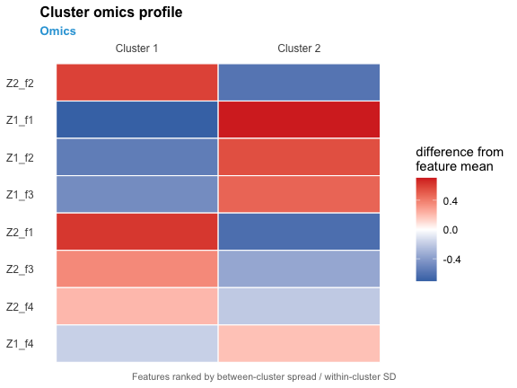

```r
prof_early[[1]]
```

Read the heatmap by row: a feature whose color alternates sharply between clusters (e.g. dark for cluster 1, light for cluster 2) is one that strongly distinguishes them; a feature with similar shading across clusters is barely contributing to the separation despite appearing in the top-`n` list.

The bar rendering shows the same features and ordering, with clusters as shades of the layer’s colour:

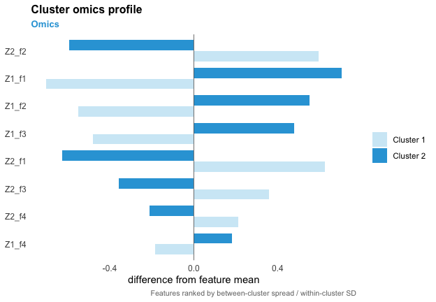

```r
plot_cluster_omic_profile(fit_early, type = "bar", top_n = 8)[[1]]
```

A parallel fit returns one plot per layer:

```r
prof_parallel <- plot_cluster_omic_profile(fit_parallel, top_n = 8)
names(prof_parallel)
```

```
## [1] "layer1" "layer2"
```

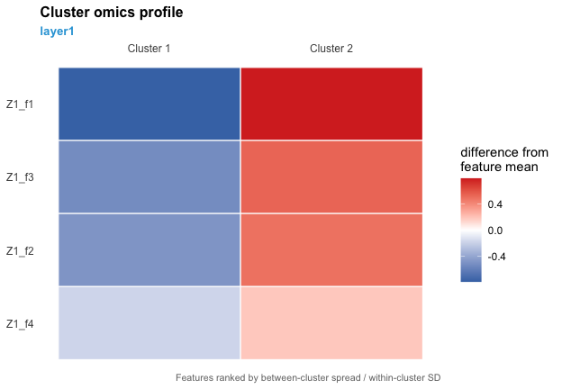

```r
prof_parallel[[1]]
```

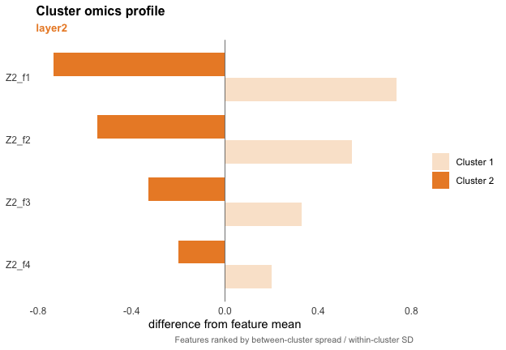

```r
plot_cluster_omic_profile(fit_parallel, type = "bar", top_n = 8)[[2]]
```

A serial fit gives one plot per stage, and one per layer within a stage that is itself a parallel sub-model:

```r
prof_serial <- plot_cluster_omic_profile(fit_serial, top_n = 8)
names(prof_serial)
```

```
## [1] "Stage 1 - layer1" "Stage 1 - layer2" "Stage 2"
```

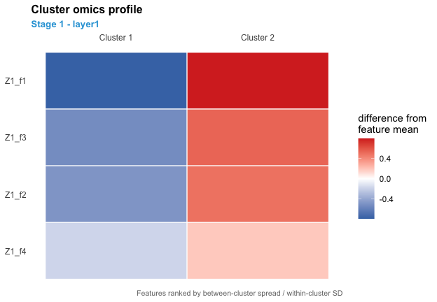

```r
prof_serial[[1]]
```

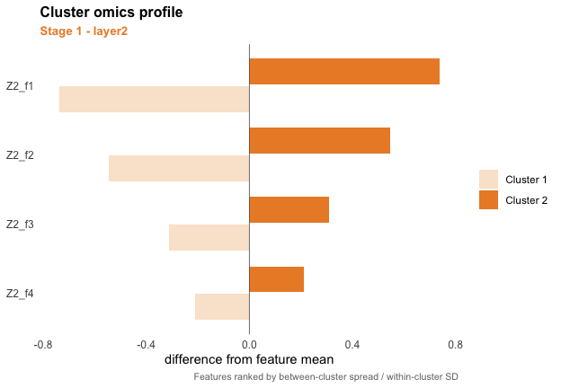

```r
plot_cluster_omic_profile(fit_serial, type = "bar", top_n = 8)[[2]]
```

### 12.3 Extracting the Ranking Directly: `get_top_omics_features()`

The importance ranking behind every panel above is also available as plain data, without generating a plot – useful for a report table, or for feeding the top features into a downstream analysis. `get_top_omics_features()` uses the exact same ranking criterion as `plot_cluster_omic_profile()` (so its output for a given `top_n` matches that plot’s panel ordering), and, like the other extractors, auto-detects the model type and returns one named numeric vector per layer/stage.

```r
top_early <- get_top_omics_features(fit_early, top_n = 5)
top_early
```

```
## $Omics
##    Z2_f2    Z1_f1    Z1_f2    Z1_f3    Z2_f1
## 1.487498 1.459852 1.246496 1.164370 1.099256
```

The names are the features, in descending order of importance score; the values are the score itself (by default, the between-cluster separation described above). This is the same top-5 that would appear in a `plot_cluster_omic_profile(fit_early, top_n = 5)` panel, just as a plain vector rather than a figure.

## 13) Binary Outcome Example (Early Model)

Everything above used a continuous outcome (`family = "normal"`). Switching to `family = "binary"` changes only the outcome model: the cluster effects on `Y` become log-odds (with odds ratios reported alongside), there is no residual variance to estimate, and `predict_lucid()`’s `response` argument lets you choose class-label or probability output. This short chunk shows that fit and a probability-scale prediction.

```r
set.seed(107)
fit_early_binary <- estimate_lucid(
  lucid_model = "early",
  G = d$G,
  Z = d$Z_early,
  Y = d$Y_binary,
  CoG = d$CoG,
  CoY = d$CoY,
  family = "binary",
  K = 2,
  max_itr = 8,
  max_tot.itr = 30,
  tol = 1e-2,
  seed = 107
)
```

```
## Fitting LUCID early model (K = 2)...
## Finished LUCID early model.
```

```r
pred_binary_prob <- predict_lucid(
  model = fit_early_binary,
  G = d$G,
  Z = d$Z_early,
  Y = d$Y_binary,
  CoG = d$CoG,
  CoY = d$CoY,
  response = FALSE
)

range(pred_binary_prob$pred.y)
```

```
## [1] 0.1039360 0.9491689
```

`pred.y` here is a probability in `[0, 1]` because `response = FALSE`; setting `response = TRUE` instead would return hard `0`/`1` class labels.

## 14) End Notes

- This guide focuses on breadth (all major exported APIs) while keeping runtime practical.
- For production analysis, you should usually increase:
  - `max_itr`, `max_tot.itr`
  - bootstrap `R`
  - tuning grid size in `tune_lucid()`
- For serial pipelines, keep a close eye on stage-wise missingness summaries.
- Under the hood, the EM optimizer that every fit in this guide runs on applies standard numerical-stability safeguards – computing sums of probabilities in log space to avoid underflow, regularizing near-singular covariance matrices, and monitoring the log-likelihood at every iteration to catch non-convergence – automatically, with no action needed from the caller. These are internal implementation details rather than part of the public API, so they are not demonstrated here.